# act_report

## Report: act_report

- Create a **250-word-minimum written report** called "act_report.pdf" or "act_report.html" that communicates the insights and displays the visualization(s) produced from your wrangled data. This is to be framed as an external document, like a blog post or magazine article, for example.

Introduction:

Dogs are considered as man's best friend and they are loved by everyone. With the rise of social media, it is now possible to share pictures and information about our furry friends with the whole world. One such platform is Twitter, where dog owners can share pictures of their dogs and rate them. The WeRateDogs Twitter account is one such platform that rates dogs and has become extremely popular over time.

Data Collection:

The data for this analysis was collected from three sources - the Twitter API, the Udacity server, and the WeRateDogs Twitter account. The data from the Twitter API included information about the tweets, retweets, and followers. The data from the Udacity server included information about the dog breeds and the predictions made by a machine learning algorithm. The data from the WeRateDogs Twitter account included information about the dogs and their ratings.

Data Wrangling:

The data was wrangled to make it suitable for analysis. This involved cleaning the data, handling missing values, and ensuring that the data was in the right format. The data was also merged to create a master dataset that included all the relevant information. The data was then unpivoted to make it easier to analyze.

Insights:

[figure not shown]

```python
import pandas as pd
import matplotlib.pyplot as plt
import numpy as np
```

```python
twitter_archive_enhanced_Master= pd.read_csv('twitter_archive_enhanced_Master.csv')
twitter_archive_enhanced_Master.info()
```

```
<class 'pandas.core.frame.DataFrame'>
RangeIndex: 581 entries, 0 to 580
Data columns (total 17 columns):
tweet_id              581 non-null int64
timestamp             581 non-null object
source                581 non-null object
text                  581 non-null object
expanded_urls         581 non-null object
rating_numerator      581 non-null float64
rating_denominator    581 non-null float64
name                  493 non-null object
favorites             581 non-null int64
retweets              581 non-null int64
user_followers        581 non-null int64
user_favourites       581 non-null int64
date_time             581 non-null object
jpg_url               581 non-null object
breed                 581 non-null object
confident_level       581 non-null float64
dog_stage             581 non-null object
dtypes: float64(3), int64(5), object(9)
memory usage: 77.2+ KB
```

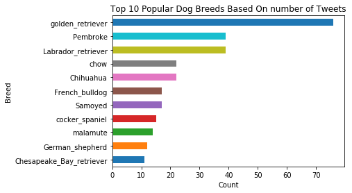

```python
# Plot bar chart for top 10 popular breeds based on number of posts

twitter_archive_enhanced_Master.breed.value_counts()[10::-1].plot(kind = 'barh', title = 'Top 10 Popular Dog Breeds Based On number of Tweets')
plt.xlabel('Count')
plt.ylabel('Breed');
```